# NonParamLines Vignette

Nicholas Hartman

11/23/2021

# Loading the NonParamLines Package

```r
devtools::install_github("nhart985/NonParamLines")
```

# LOESS Smoother (Cleveland, 1979)

## Example 1: Cars Data from the stats Package

The smooth predictions from the loess_fit() function can be plotted on top of the data to show the general trend of the data. Here is a comparison with the loess() function from the stats package in R:

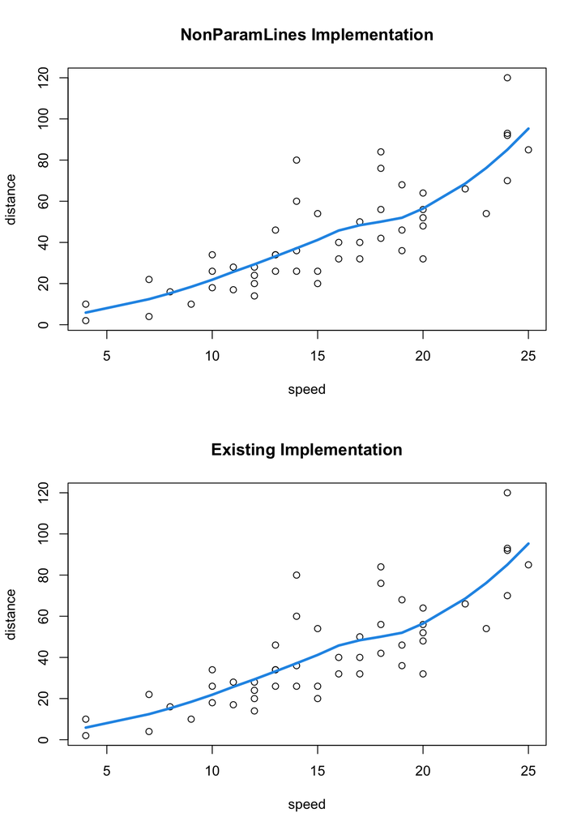

```r
set.seed(1)
data(cars)
speed=cars$speed
distance=cars$dist
par(mfrow=c(2,1))
plot(speed,distance,main="NonParamLines Implementation")
lines(speed,NonParamLines::loess_fit(speed,distance),col=4,lwd=3)
plot(speed,distance,main="Existing Implementation")
lines(speed,predict(stats::loess(distance~speed,surface="direct")),col=4,lwd=3)
```

The smoothed curves in the above plots look identical, and this can be confirmed using the all.equal() function:

```r
all.equal(NonParamLines::loess_fit(speed,distance),
          predict(stats::loess(distance~speed,surface="direct")))
```

```
## [1] TRUE
```

Since the above code returns TRUE, it indicates that the predictions are equal within a very minor tolerance. We now check the computational speed of the implementation in comparison to the existing implementation:

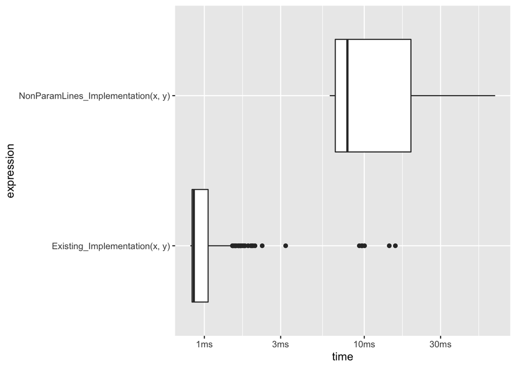

```r
NonParamLines_Implementation=function(x,y) {
  return(NonParamLines::loess_fit(speed,distance))
}
Existing_Implementation=function(x,y) {
  return(predict(stats::loess(distance~speed,surface="direct")))
}
x=speed
y=distance
plot(bench::mark(NonParamLines_Implementation(x,y),
     Existing_Implementation(x,y)),type="boxplot")
```

The NonParamLines implementation is about 10 times slower, which is expected since loops are unavoidable in the LOESS algorithm and the existing implementation uses C++.

## Example 2: A More Complicated Relationship

In this next example, we apply the loess_fit() function to data which has a more interesting shape. We also explore the impact of changing the degree and span parameters. The former determines if local linear or quadratic models are fit (default is quadratic) and the latter determines what proportion of the data is included in each local fit:

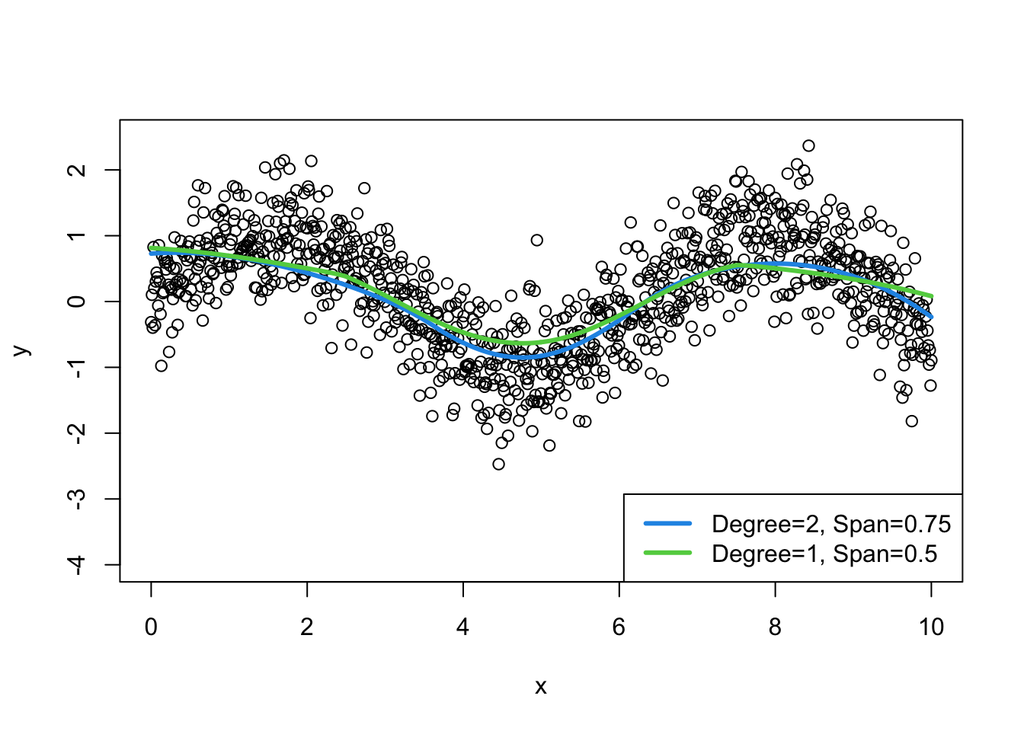

```r
set.seed(1)
x=seq(0,10,length.out=1000)
y=sin(x)+rnorm(1000,0,0.5)
par(mfrow=c(1,1))
plot(x,y,ylim=c(-4,2.5))
lines(x,NonParamLines::loess_fit(x,y),col=4,lwd=3) #Quadratic, Span=0.75
lines(x,NonParamLines::loess_fit(x,y,degree=1,span=0.5),col=3,lwd=3) #Linear, Span=0.5
legend("bottomright",legend=c("Degree=2, Span=0.75","Degree=1, Span=0.5"),
       col=c(4,3),lwd=c(3,3),lty=c(1,1))
```

Again, we can compare the predictions to those from an existing implemention using all.equal():

```r
all.equal(NonParamLines::loess_fit(x,y),
          predict(stats::loess(y~x,surface="direct")))
```

```
## [1] TRUE
```

```r
all.equal(NonParamLines::loess_fit(x,y,degree=1,span=0.5),
          predict(stats::loess(y~x,degree=1,span=0.5,surface="direct")))
```

```
## [1] TRUE
```

Since the above code returns TRUE for both settings, it indicates that the predictions are equal to the existing implementation within a very minor tolerance.

# Friedman’s Super Smoother (Friedman, 1984) with Fixed Span

## Example

We use Example 2 from the previous section to demonstrate the supsmu_fit() function and the span argument usage:

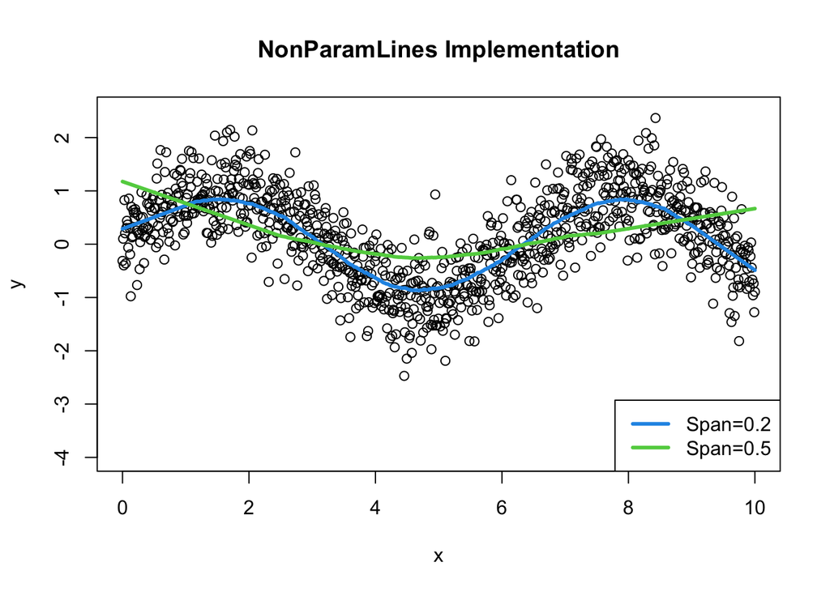

```r
set.seed(1)
x=seq(0,10,length.out=1000)
y=sin(x)+rnorm(1000,0,0.5)
plot(x,y,main="NonParamLines Implementation",ylim=c(-4,2.5))
lines(x,NonParamLines::supsmu_fit(x,y,span=0.2),col=4,lwd=3) #Span=0.2
lines(x,NonParamLines::supsmu_fit(x,y,span=0.5),col=3,lwd=3) #Span=0.5
legend("bottomright",legend=c("Span=0.2","Span=0.5"),
       col=c(4,3),lwd=c(3,3),lty=c(1,1))
```

We compare the predictions to those from an existing implemention using all.equal():

```r
all.equal(NonParamLines::supsmu_fit(x,y,span=0.2),supsmu(x,y,span=0.2)$y)
```

```
## [1] TRUE
```

```r
all.equal(NonParamLines::supsmu_fit(x,y,span=0.5),supsmu(x,y,span=0.5)$y)
```

```
## [1] TRUE
```

Since the above code returns TRUE for both settings, it indicates that the predictions are equal to the existing implementation within a very minor tolerance. We now demonstrate the computational speed:

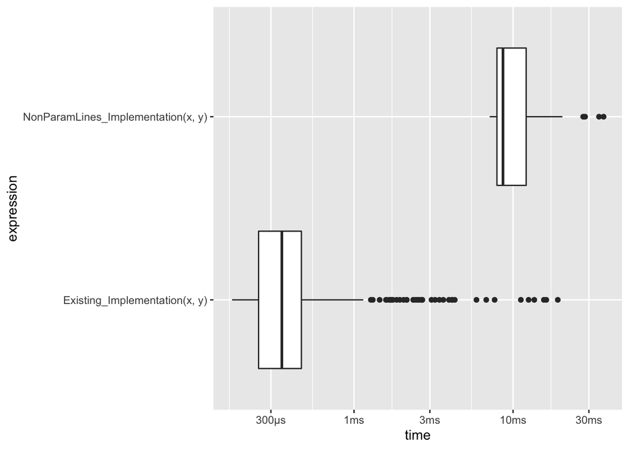

```r
NonParamLines_Implementation=function(x,y) {
  return(NonParamLines::supsmu_fit(x,y,span=0.2))
}
Existing_Implementation=function(x,y) {
  return(supsmu(x,y,span=0.2)$y)
}
plot(bench::mark(NonParamLines_Implementation(x,y),
     Existing_Implementation(x,y)),type="boxplot")
```

The NonParamLines implementation is slower, which is expected since loops are unavoidable in the running lines algorithm and the existing implementation uses FORTRAN.

# Friedman’s Super Smoother (Friedman, 1984) with Variable Span

We now demonstrate the supsmu_fit() function using a variable span (leaving the span argument as NULL) and different choices of the bass argument:

## Example 1: A Weak Linear Relationship

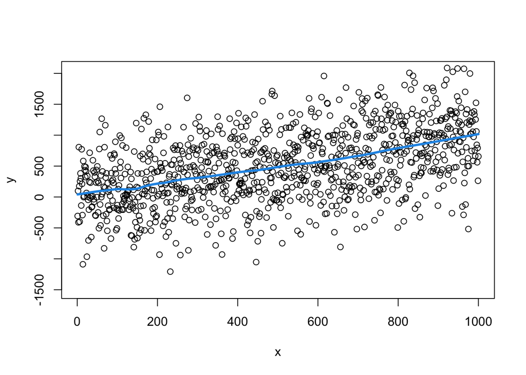

```r
set.seed(1)
x=(1:1000)
y=x+rnorm(1000,5,500)
plot(x,y,ylim=c(-1500,2050))
lines(sort(x),NonParamLines::supsmu_fit(x,y),col=4,lwd=3)
```

```r
all.equal(NonParamLines::supsmu_fit(x,y),supsmu(x,y)$y)
```

```
## [1] TRUE
```

## Example 2: A More Complicated Relationship

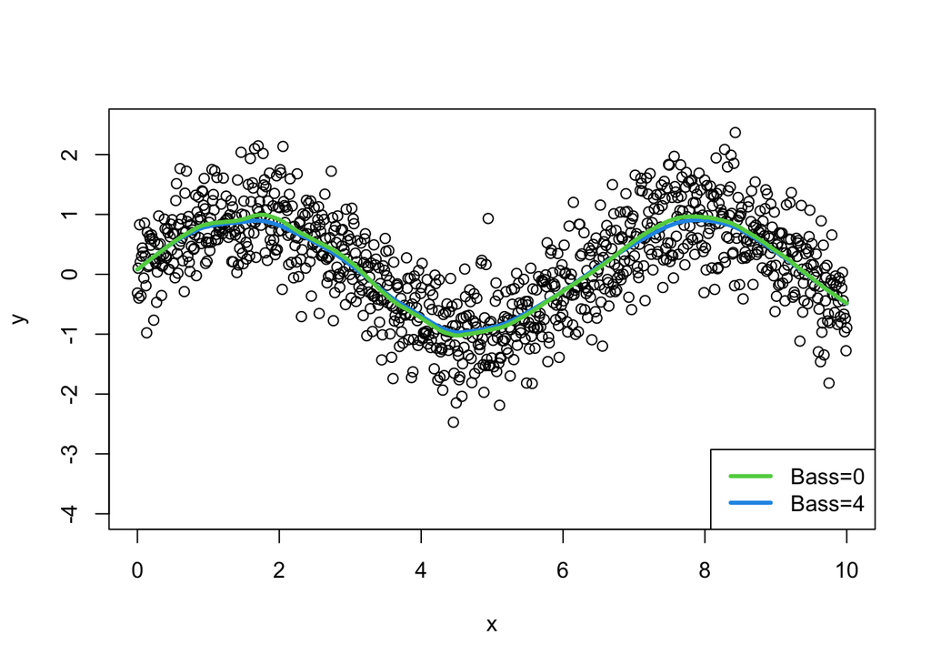

```r
set.seed(1)
x=seq(0,10,length.out=1000)
y=sin(x)+rnorm(1000,0,0.5)
plot(x,y,ylim=c(-4,2.5))
lines(sort(x),NonParamLines::supsmu_fit(x,y,bass=4),col=4,lwd=3) #Bass=4
lines(sort(x),NonParamLines::supsmu_fit(x,y),col=3,lwd=3) #Bass=0
legend("bottomright",legend=c("Bass=0","Bass=4"),
       col=c(3,4),lwd=c(3,3),lty=c(1,1))
```

```r
all.equal(NonParamLines::supsmu_fit(x,y,bass=4),supsmu(x,y,bass=4)$y)
```

```
## [1] TRUE
```

```r
all.equal(NonParamLines::supsmu_fit(x,y),supsmu(x,y)$y)
```

```
## [1] TRUE
```

Since the above code returns TRUE for all settings, it indicates that the predictions are equal to the existing implementation within a very minor tolerance. We now demonstrate the computational speed:

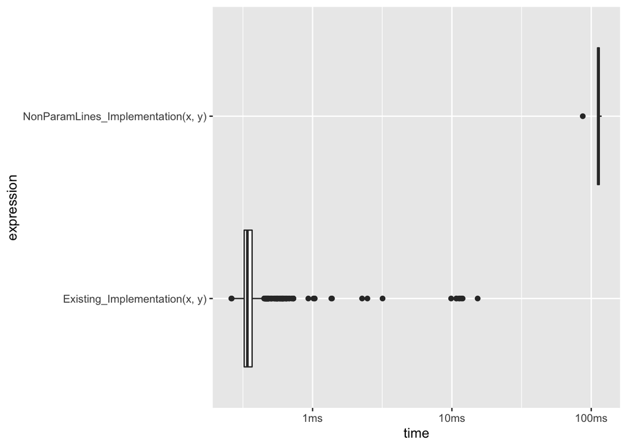

```r
NonParamLines_Implementation=function(x,y) {
  return(NonParamLines::supsmu_fit(x,y))
}
Existing_Implementation=function(x,y) {
  return(supsmu(x,y)$y)
}
plot(bench::mark(NonParamLines_Implementation(x,y),
     Existing_Implementation(x,y)),type="boxplot")
```

The NonParamLines implementation is slower, which is expected since loops are unavoidable in the running lines algorithm and the existing implementation uses FORTRAN.